```
## 'data.frame':    17232 obs. of  241 variables:
##  $ SITE     : chr  "XX" "XX" "XX" "XX" ...
##  $ NOTHING  : chr  "" "" "" "" ...
##  $ Q1       : chr  "5" "4" "4" "4" ...
##  $ Q2       : chr  "1" "2" "2" "2" ...
##  $ Q3       : chr  "3" "" "2" "2" ...
##  $ Q4       : chr  "2" "1" "1" "1" ...
##  $ Q5       : chr  "C" "A  DE" "" "" ...
##  $ Q6       : chr  "1.57" "" "1.70" "1.75" ...
##  $ Q7       : chr  "70.31" "" "61.69" "60.33" ...
##  $ Q8       : chr  "5" "4" "5" "4" ...
##  $ Q9       : chr  "4" "3" "1" "1" ...
##  $ Q10      : chr  "1" "1" "1" "2" ...
##  $ Q11      : chr  "1" "1" "1" "2" ...
##  $ Q12      : chr  "1" "1" "1" "1" ...
```

[output cut: 86 more lines]

```r
v2k <- c('Q1',  'Q2',   'Q3',   'Q4',   'RACEETH',  'Q8', 'QN8',    'Q9', 'QN9', 'Q10', 'QN10', 'Q11', 'QN11',  'Q12', 'QN12',  'Q13', 'QN13',  'Q14', 'QN14',  'Q15', 'QN15',  'Q16', 'QN16',  'Q17', 'QN17',  'Q18', 'QN18',  'Q19', 'QN19',  'Q20', 'QN20',  'Q21',  'Q22', 'QN22',  'Q23', 'QN23',  'Q24', 'QN24',  'Q25', 'QN25',  'Q26', 'QN26',  'Q27',  'Q28', 'QN28',  'Q29',  'Q30', 'QN30',  'Q31', 'QN31',  'Q32', 'QN32',  'Q33', 'QN33',  'Q34', 'QN34',  'Q35',  'Q36',  'Q37', 'QN37',  'Q38', 'QN38',  'Q40', 'QN40',  'Q41', 'QN41',  'Q42', 'QN42',  'Q43',  'Q44', 'QN44',  'Q45', 'QN45',  'Q46', 'QN46',  'Q47',  'Q48',  'Q49', 'QN49',  'Q50', 'QN50',  'Q51',  'Q52', 'QN52',  'Q53', 'QN53',  'Q54',  'Q55', 'QN55',  'Q56', 'QN56',  'Q57', 'QN57',  'Q58', 'QN58',  'Q59', 'QN59',  'Q60',  'Q61',  'Q62', 'QN62',  'Q63', 'QN63',  'Q64',  'Q65',  'Q68',  'Q69', 'QN69',  'Q70',  'Q71',  'Q72',  'Q73', 'QN73',  'Q74',  'Q76',  'Q77', 'QN77',  'Q78',  'Q79',  'Q80',  'Q82', 'QN82',  'Q83', 'QN83',  'Q84', 'QN84',  'Q85', 'QN85', 'Q86',   'Q87', 'QN87',  'Q88', 'QN88',  'Q89',  'Q93', 'QN93',  'Q95',  'Q96', 'QN96', 'QN97', 'QN99', 'Q99')
```

```r
'%!in%' <- Negate('%in%') #not in function. shows which variables are not in the dataset. should be 0
```

```r
v2k[which(v2k %!in% names(dat))]
```

```
## character(0)
```

```r
sdat <- dat[,v2k]
```

```r
sdat$Q2 <- factor(sdat$Q2, levels=rev(1:2), labels=rev(c("Female", "Male")))
sdat$QN85 <- factor(sdat$QN85, levels=rev(1:2), labels=rev(c("Yes", "No")))
sdat$Q4 <- factor(sdat$Q4, levels=rev(1:2), labels=rev(c("Yes", "No")))
sdat$QN8 <- factor(sdat$QN8, levels=rev(1:2), labels=rev(c("Yes", "No")))
sdat$QN9 <- factor(sdat$QN9, levels=rev(1:2), labels=rev(c("Yes", "No")))
sdat$QN10 <- factor(sdat$QN10, levels=rev(1:2), labels=rev(c("Yes", "No")))
sdat$QN11 <- factor(sdat$QN11, levels=rev(1:2), labels=rev(c("Yes", "No")))
sdat$QN12 <- factor(sdat$QN12, levels=rev(1:2), labels=rev(c("Yes", "No")))
sdat$QN13 <- factor(sdat$QN13, levels=rev(1:2), labels=rev(c("Yes", "No")))
sdat$QN14 <- factor(sdat$QN14, levels=rev(1:2), labels=rev(c("Yes", "No")))
sdat$QN15 <- factor(sdat$QN15, levels=rev(1:2), labels=rev(c("Yes", "No")))
sdat$QN16 <- factor(sdat$QN16, levels=rev(1:2), labels=rev(c("Yes", "No")))
sdat$QN17 <- factor(sdat$QN17, levels=rev(1:2), labels=rev(c("Yes", "No")))
sdat$QN18 <- factor(sdat$QN18, levels=rev(1:2), labels=rev(c("Yes", "No")))
sdat$QN19 <- factor(sdat$QN19, levels=rev(1:2), labels=rev(c("Yes", "No")))
sdat$QN20 <- factor(sdat$QN20, levels=rev(1:2), labels=rev(c("Yes", "No")))
sdat$QN22 <- factor(sdat$QN22, levels=rev(1:2), labels=rev(c("Yes", "No")))
sdat$QN23 <- factor(sdat$QN23, levels=rev(1:2), labels=rev(c("Yes", "No")))
sdat$QN24 <- factor(sdat$QN24, levels=rev(1:2), labels=rev(c("Yes", "No")))
sdat$QN25 <- factor(sdat$QN25, levels=rev(1:2), labels=rev(c("Yes", "No")))
sdat$QN26 <- factor(sdat$QN26, levels=rev(1:2), labels=rev(c("Yes", "No")))
sdat$QN28 <- factor(sdat$QN28, levels=rev(1:2), labels=rev(c("Yes", "No")))
sdat$QN30 <- factor(sdat$QN30, levels=rev(1:2), labels=rev(c("Yes", "No")))
sdat$QN31 <- factor(sdat$QN31, levels=rev(1:2), labels=rev(c("Yes", "No")))
sdat$QN32 <- factor(sdat$QN32, levels=rev(1:2), labels=rev(c("Yes", "No")))
sdat$QN33 <- factor(sdat$QN33, levels=rev(1:2), labels=rev(c("Yes", "No")))
sdat$QN34 <- factor(sdat$QN34, levels=rev(1:2), labels=rev(c("Yes", "No")))
sdat$QN37 <- factor(sdat$QN37, levels=rev(1:2), labels=rev(c("Yes", "No")))
sdat$QN38 <- factor(sdat$QN38, levels=rev(1:2), labels=rev(c("Yes", "No")))
sdat$QN40 <- factor(sdat$QN40, levels=rev(1:2), labels=rev(c("Yes", "No")))
sdat$QN41 <- factor(sdat$QN41, levels=rev(1:2), labels=rev(c("Yes", "No")))
sdat$QN42 <- factor(sdat$QN42, levels=rev(1:2), labels=rev(c("Yes", "No")))
sdat$QN44 <- factor(sdat$QN44, levels=rev(1:2), labels=rev(c("Yes", "No")))
sdat$QN45 <- factor(sdat$QN45, levels=rev(1:2), labels=rev(c("Yes", "No")))
sdat$QN46 <- factor(sdat$QN46, levels=rev(1:2), labels=rev(c("Yes", "No")))
sdat$QN49 <- factor(sdat$QN49, levels=rev(1:2), labels=rev(c("Yes", "No")))
sdat$QN50 <- factor(sdat$QN50, levels=rev(1:2), labels=rev(c("Yes", "No")))
sdat$QN52 <- factor(sdat$QN52, levels=rev(1:2), labels=rev(c("Yes", "No")))
sdat$QN53 <- factor(sdat$QN53, levels=rev(1:2), labels=rev(c("Yes", "No")))
sdat$QN55 <- factor(sdat$QN55, levels=rev(1:2), labels=rev(c("Yes", "No")))
sdat$QN56 <- factor(sdat$QN56, levels=rev(1:2), labels=rev(c("Yes", "No")))
sdat$QN57 <- factor(sdat$QN57, levels=rev(1:2), labels=rev(c("Yes", "No")))
sdat$QN58 <- factor(sdat$QN58, levels=rev(1:2), labels=rev(c("Yes", "No")))
sdat$QN59 <- factor(sdat$QN59, levels=rev(1:2), labels=rev(c("Yes", "No")))
sdat$QN62 <- factor(sdat$QN62, levels=rev(1:2), labels=rev(c("Yes", "No")))
sdat$QN69 <- factor(sdat$QN69, levels=rev(1:2), labels=rev(c("Yes", "No")))
sdat$QN73 <- factor(sdat$QN73, levels=rev(1:2), labels=rev(c("Yes", "No")))
sdat$QN77 <- factor(sdat$QN77, levels=rev(1:2), labels=rev(c("Yes", "No")))
sdat$QN82 <- factor(sdat$QN82, levels=rev(1:2), labels=rev(c("Yes", "No")))
sdat$QN83 <- factor(sdat$QN83, levels=rev(1:2), labels=rev(c("Yes", "No")))
sdat$QN84 <- factor(sdat$QN84, levels=rev(1:2), labels=rev(c("Yes", "No")))
sdat$QN87 <- factor(sdat$QN87, levels=rev(1:2), labels=rev(c("Yes", "No")))
sdat$QN88 <- factor(sdat$QN88, levels=rev(1:2), labels=rev(c("Yes", "No")))
sdat$QN93 <- factor(sdat$QN93, levels=rev(1:2), labels=rev(c("Yes", "No")))
sdat$QN96 <- factor(sdat$QN96, levels=rev(1:2), labels=rev(c("Yes", "No")))
sdat$QN97 <- factor(sdat$QN97, levels=rev(1:2), labels=rev(c("Yes", "No")))
sdat$QN99 <- factor(sdat$QN99, levels=rev(1:2), labels=rev(c("Yes", "No")))
```

```r
tab <- table(sdat$Q2); tab
```

```
##
##   Male Female
##   8816   8152
```

```r
ptab <- prop.table(tab); ptab
```

```
##
##      Male    Female
## 0.5195662 0.4804338
```

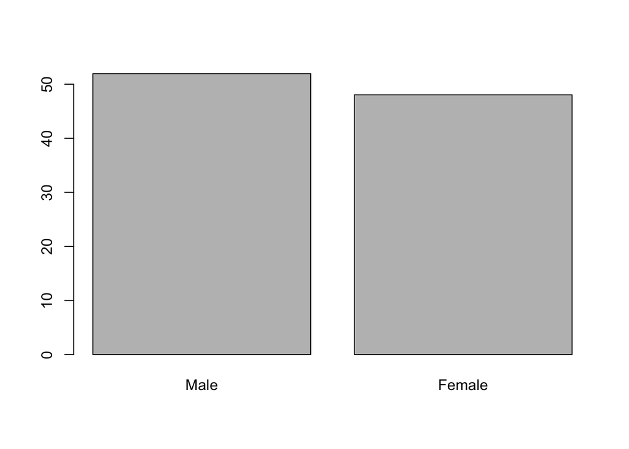

```r
barplot(ptab*100)
```

```r
table(sdat$Q2, sdat$QN85, useNA="ifany")
```

```
##
##            No  Yes <NA>
##   Male   5337 1178 2301
##   Female 3634 2465 2053
##   <NA>     95   86   83
```

```r
tab <- table(sdat$Q2, sdat$QN85)
ptab <- prop.table(tab); ptab
```

```
##
##                 No       Yes
##   Male   0.4231013 0.0933883
##   Female 0.2880926 0.1954178
```

Based on the contigency table, females reported having mental health that wasn’t good the majority of the time as opposed to males.

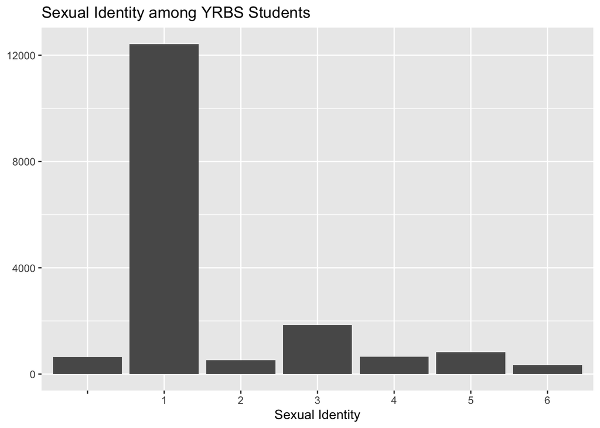

```r
ggplot(data = sdat, mapping = aes(x = Q65)) +
  geom_bar() +
  labs(title = "Sexual Identity among YRBS Students", #1=Heterosexual(straight), 2=GayOrLesbian, 3=Bisexual
       x = "Sexual Identity",                         #
       y = NULL)
```

```r
sdat <- sdat %>%
  mutate(sexual_identity = case_when(Q65 == 1 ~ "Heterosexual",
                                    Q65 == 2 ~ "Gay or Lesbian",
                                    Q65 == 3 ~ "Bisexual",
                                    Q65 == 4 ~ "Other Identity",
                                    Q65 == 5 ~ "Other Identity",
                                  TRUE ~ NA))
```

```r
sdat$sexual_identity2 <- factor(ifelse(sdat$sexual_identity == "Heterosexual", "Heterosexual", "Sexual Minority"))
#This creates a dichotomous sexual identity variable
```

```r
table(sdat$sexual_identity)
```

```
##
##       Bisexual Gay or Lesbian   Heterosexual Other Identity
##           1848            520          12421           1482
```

```r
table(sdat$sexual_identity2)
```

```
##
##    Heterosexual Sexual Minority
##           12421            3850
```

Although the first code chunk gave each response for Q65 a category/sexual identity, the second dichotomous variable will facilitate the analyses. Since some categories don’t have enough data/very few data, there’s an issue when running the analyses and the creation of a dichotomous variable allows for fewer and broader categories.

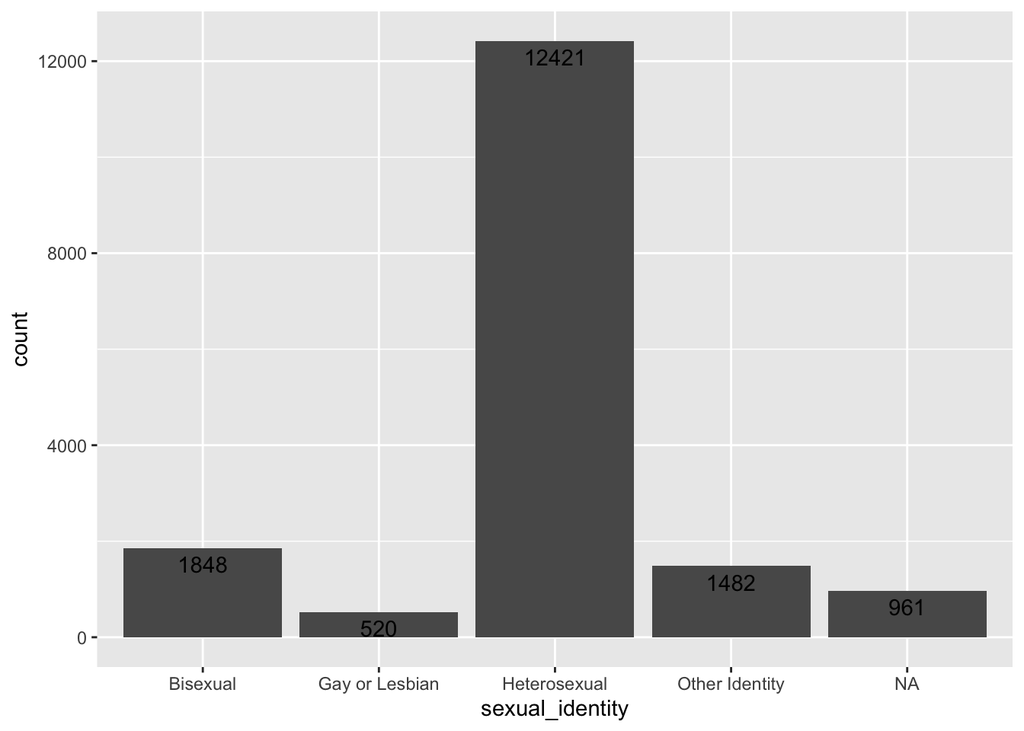

```r
ggplot(data = sdat, mapping = aes(x = sexual_identity)) + #put in descending order?? #add color??
  geom_bar() +        #add quantity to bars??
  geom_text(aes(label = ..count..), stat = "count", vjust = 1.5, color = "black")
```

```r
  labs(title = "Sexual Identity among YRBS Students",
       x = NULL,
       y = NULL)
```

```
## $x
## NULL
##
## $y
## NULL
##
## $title
## [1] "Sexual Identity among YRBS Students"
##
## attr(,"class")
## [1] "labels"
```

```r
sdat %>%
  count(sexual_identity)
```

```
##   sexual_identity     n
## 1        Bisexual  1848
## 2  Gay or Lesbian   520
## 3    Heterosexual 12421
## 4  Other Identity  1482
## 5            <NA>   961
```

Most students within this dataset identity as Heterosexual (straight).

```r
sdat <- sdat %>%
  mutate(grade_level = case_when(Q3 == 1 ~ "9th",
                                 Q3 == 2 ~ "10th",
                                 Q3 == 3 ~ "12th",
                                 TRUE ~ "Other"))
```

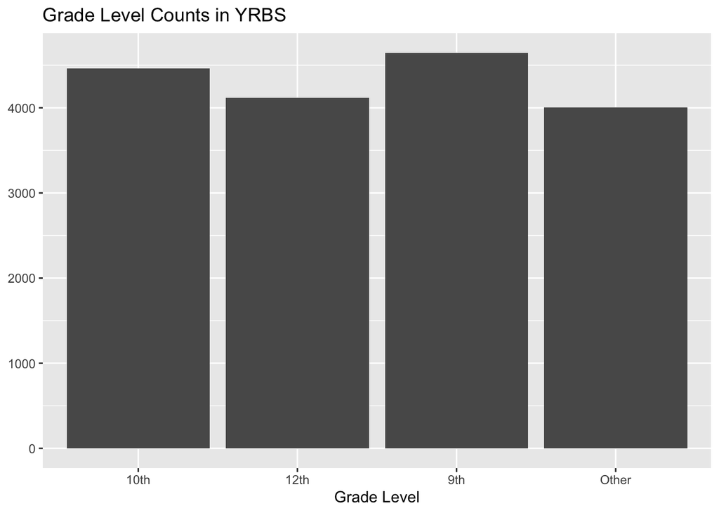

```r
ggplot(data = sdat, mapping = aes(x = grade_level)) + #put into descending order
  geom_bar() +
  labs(title = "Grade Level Counts in YRBS",
       x = "Grade Level",
       y = NULL)
```

The grade level with most participants within the YRBS are 9th graders.

```r
sdat <- sdat %>%
  mutate(raceneth = case_when(
    RACEETH == 1 ~ "Indian/Alaska Native",
    RACEETH == 2 ~ "Asian",
    RACEETH == 3 ~ "Black/African American",
    RACEETH == 4 ~ "Native Hawaiian/Other PI",
    RACEETH == 5 ~ "White",
    RACEETH == 6 ~ "Hispanic/Latino",
    RACEETH == 7 ~ "Hispanic/Latino",
    RACEETH == 8 ~ "Other",
    TRUE ~ "Other"
  ))
```

```r
sdat$raceneth2 <- factor(ifelse(sdat$raceneth == "White", "White", ifelse(sdat$raceneth == "Black/African American", "Black/AA", ifelse(sdat$raceneth == "Hispanic/Latino", "Hispanic/Latino", "Other"))))
```

```r
sdat$raceneth2 <- relevel(sdat$raceneth2, ref="White") #Code makes White individuals the reference (base-line)
```

The code above creates a new variable with 4 levels as opposed to 7 levels. Like variable Q65, having more levels results in fewer outcomes for each level at the time of analyses which causes troubles in the analyses. Fewer categories allows for larger outcomes in each category.

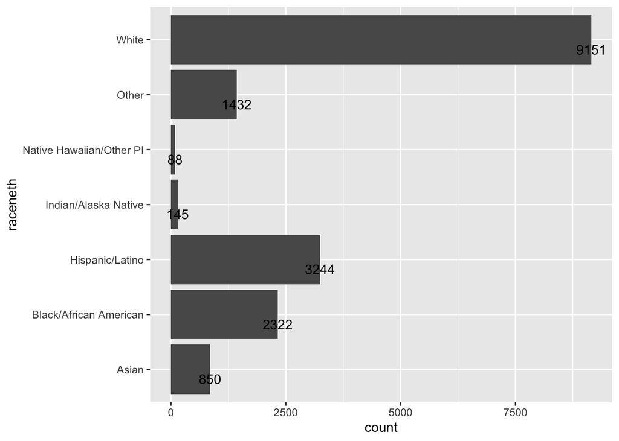

```r
ggplot(data = sdat, mapping = aes(y = raceneth)) +
  geom_bar() +
  geom_text(aes(label = ..count..), stat = "count", vjust = 1.5, color = "black")
```

```r
  labs(x = NULL,
       y = NULL,
       title = "Race/Ethnicity Distribution in YRBS")
```

```
## $x
## NULL
##
## $y
## NULL
##
## $title
## [1] "Race/Ethnicity Distribution in YRBS"
##
## attr(,"class")
## [1] "labels"
```

Students of white race are the most common within the YRBS.

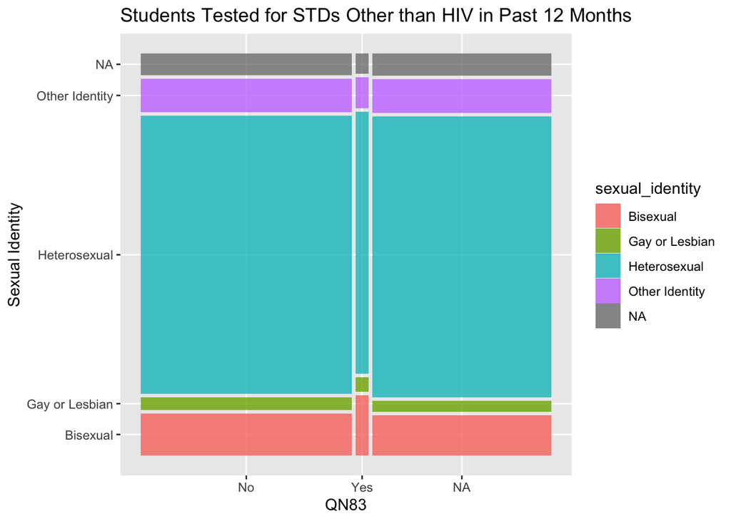

```r
ggplot(data = sdat) +
  geom_mosaic(aes(x = product(QN83),
                  fill = sexual_identity)) +
  labs(title = "Students Tested for STDs Other than HIV in Past 12 Months",
       y = "Sexual Identity")
```

```r
tab <- table(sdat$QN83); tab
```

```
##
##   No  Yes
## 9033  542
```

```r
ptab <- prop.table(tab); ptab
```

```
##
##         No        Yes
## 0.94339426 0.05660574
```

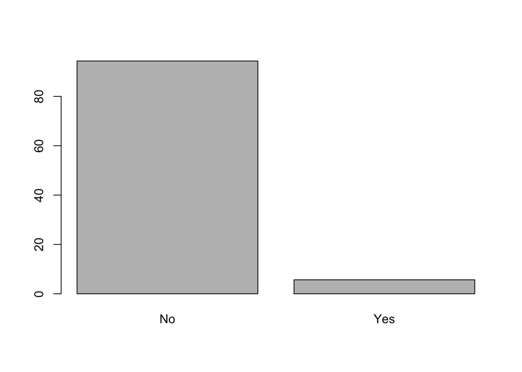

```r
barplot(ptab*100)
```

94.34% of students were not tested for STDS other than hIV within the last 12 months.

```r
table(sdat$Q2, sdat$QN83, useNA="ifany")
```

```
##
##            No  Yes <NA>
##   Male   4689  229 3898
##   Female 4212  302 3638
##   <NA>    132   11  121
```

```r
tab <- table(sdat$Q2, sdat$QN83)
ptab <- prop.table(tab); ptab
```

```
##
##                  No        Yes
##   Male   0.49713740 0.02427905
##   Female 0.44656489 0.03201866
```

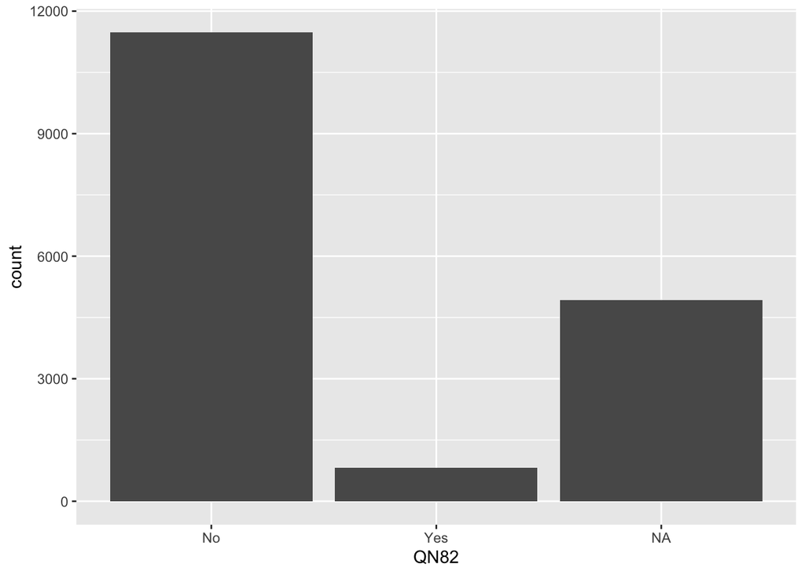

```r
ggplot(data = sdat, mapping = aes(x = QN82)) +
  geom_bar()
```

```r
heterosexualdata <- sdat %>%
  filter(sexual_identity == "Heterosexual")
```

```r
heterosexualdata %>%
  count(raceneth, QN10)
```

```
##                    raceneth QN10    n
## 1                     Asian   No  214
## 2                     Asian  Yes    5
## 3                     Asian <NA>  368
## 4    Black/African American   No  740
## 5    Black/African American  Yes   18
## 6    Black/African American <NA>  926
## 7           Hispanic/Latino   No 1084
## 8           Hispanic/Latino  Yes   66
## 9           Hispanic/Latino <NA> 1211
## 10     Indian/Alaska Native   No   43
## 11     Indian/Alaska Native  Yes    2
## 12     Indian/Alaska Native <NA>   52
## 13 Native Hawaiian/Other PI   No   18
## 14 Native Hawaiian/Other PI <NA>   44
## 15                    Other   No  384
## 16                    Other  Yes   18
## 17                    Other <NA>  485
## 18                    White   No 3910
## 19                    White  Yes  169
## 20                    White <NA> 2664
```

```r
heterosexualdata %>%
  count(raceneth, QN11)
```

```
##                    raceneth QN11    n
## 1                     Asian   No  167
## 2                     Asian  Yes   57
## 3                     Asian <NA>  363
## 4    Black/African American   No  605
## 5    Black/African American  Yes  241
## 6    Black/African American <NA>  838
## 7           Hispanic/Latino   No  804
## 8           Hispanic/Latino  Yes  417
## 9           Hispanic/Latino <NA> 1140
## 10     Indian/Alaska Native   No   34
## 11     Indian/Alaska Native  Yes   11
## 12     Indian/Alaska Native <NA>   52
## 13 Native Hawaiian/Other PI   No   13
## 14 Native Hawaiian/Other PI  Yes    7
## 15 Native Hawaiian/Other PI <NA>   42
## 16                    Other   No  275
## 17                    Other  Yes  138
## 18                    Other <NA>  474
## 19                    White   No 2267
## 20                    White  Yes 1693
## 21                    White <NA> 2783
```

```r
heterosexualdata %>%
  count(raceneth, QN13)
```

```
##                    raceneth QN13    n
## 1                     Asian   No  434
## 2                     Asian  Yes    4
## 3                     Asian <NA>  149
## 4    Black/African American   No 1509
## 5    Black/African American  Yes   95
## 6    Black/African American <NA>   80
## 7           Hispanic/Latino   No 2034
## 8           Hispanic/Latino  Yes  101
## 9           Hispanic/Latino <NA>  226
## 10     Indian/Alaska Native   No   69
## 11     Indian/Alaska Native  Yes    7
## 12     Indian/Alaska Native <NA>   21
## 13 Native Hawaiian/Other PI   No   37
## 14 Native Hawaiian/Other PI  Yes    3
## 15 Native Hawaiian/Other PI <NA>   22
## 16                    Other   No  670
## 17                    Other  Yes   28
## 18                    Other <NA>  189
## 19                    White   No 4215
## 20                    White  Yes  183
## 21                    White <NA> 2345
```

```r
heterosexualdata %>%
  count(raceneth, QN28)
```

```
##                    raceneth QN28    n
## 1                     Asian   No  508
## 2                     Asian  Yes   27
## 3                     Asian <NA>   52
## 4    Black/African American   No 1251
## 5    Black/African American  Yes  165
## 6    Black/African American <NA>  268
## 7           Hispanic/Latino   No 1873
## 8           Hispanic/Latino  Yes  183
## 9           Hispanic/Latino <NA>  305
## 10     Indian/Alaska Native   No   75
## 11     Indian/Alaska Native  Yes    9
## 12     Indian/Alaska Native <NA>   13
## 13 Native Hawaiian/Other PI   No   53
## 14 Native Hawaiian/Other PI  Yes    5
## 15 Native Hawaiian/Other PI <NA>    4
## 16                    Other   No  727
## 17                    Other  Yes   75
## 18                    Other <NA>   85
## 19                    White   No 5897
## 20                    White  Yes  391
## 21                    White <NA>  455
```

```r
heterosexualdata %>%
  count(raceneth, QN83)
```

```
##                    raceneth QN83    n
## 1                     Asian   No  357
## 2                     Asian  Yes    9
## 3                     Asian <NA>  221
## 4    Black/African American   No  990
## 5    Black/African American  Yes   79
## 6    Black/African American <NA>  615
## 7           Hispanic/Latino   No 1469
## 8           Hispanic/Latino  Yes   95
## 9           Hispanic/Latino <NA>  797
## 10     Indian/Alaska Native   No   53
## 11     Indian/Alaska Native  Yes    3
## 12     Indian/Alaska Native <NA>   41
## 13 Native Hawaiian/Other PI   No   25
## 14 Native Hawaiian/Other PI  Yes    1
## 15 Native Hawaiian/Other PI <NA>   36
## 16                    Other   No  437
## 17                    Other  Yes   40
## 18                    Other <NA>  410
## 19                    White   No 3163
## 20                    White  Yes  140
## 21                    White <NA> 3440
```

```r
heterosexualdata %>%
  count(raceneth, QN30)
```

```
##                    raceneth QN30    n
## 1                     Asian   No  461
## 2                     Asian  Yes   29
## 3                     Asian <NA>   97
## 4    Black/African American   No 1004
## 5    Black/African American  Yes  111
## 6    Black/African American <NA>  569
## 7           Hispanic/Latino   No 1460
## 8           Hispanic/Latino  Yes  334
## 9           Hispanic/Latino <NA>  567
## 10     Indian/Alaska Native   No   62
## 11     Indian/Alaska Native  Yes   17
## 12     Indian/Alaska Native <NA>   18
## 13 Native Hawaiian/Other PI   No   43
## 14 Native Hawaiian/Other PI  Yes    7
## 15 Native Hawaiian/Other PI <NA>   12
## 16                    Other   No  550
## 17                    Other  Yes   99
## 18                    Other <NA>  238
## 19                    White   No 4735
## 20                    White  Yes  918
## 21                    White <NA> 1090
```

```r
heterosexualdata %>%
  count(raceneth, QN41)
```

```
##                    raceneth QN41    n
## 1                     Asian   No  518
## 2                     Asian  Yes   46
## 3                     Asian <NA>   23
## 4    Black/African American   No 1375
## 5    Black/African American  Yes  183
## 6    Black/African American <NA>  126
## 7           Hispanic/Latino   No 1729
## 8           Hispanic/Latino  Yes  478
## 9           Hispanic/Latino <NA>  154
## 10     Indian/Alaska Native   No   70
## 11     Indian/Alaska Native  Yes   24
## 12     Indian/Alaska Native <NA>    3
## 13 Native Hawaiian/Other PI   No   46
## 14 Native Hawaiian/Other PI  Yes   10
## 15 Native Hawaiian/Other PI <NA>    6
## 16                    Other   No  669
## 17                    Other  Yes  169
## 18                    Other <NA>   49
## 19                    White   No 4840
## 20                    White  Yes 1635
## 21                    White <NA>  268
```

```r
heterosexualdata %>%
  count(raceneth, QN59)
```

```
##                    raceneth QN59    n
## 1                     Asian   No  542
## 2                     Asian  Yes    8
## 3                     Asian <NA>   37
## 4    Black/African American   No 1320
## 5    Black/African American  Yes  123
## 6    Black/African American <NA>  241
## 7           Hispanic/Latino   No 1963
## 8           Hispanic/Latino  Yes  156
## 9           Hispanic/Latino <NA>  242
## 10     Indian/Alaska Native   No   85
## 11     Indian/Alaska Native  Yes    7
## 12     Indian/Alaska Native <NA>    5
## 13 Native Hawaiian/Other PI   No   52
## 14 Native Hawaiian/Other PI  Yes    2
## 15 Native Hawaiian/Other PI <NA>    8
## 16                    Other   No  752
## 17                    Other  Yes   52
## 18                    Other <NA>   83
## 19                    White   No 5995
## 20                    White  Yes  364
## 21                    White <NA>  384
```

```r
heterosexualdata %>%
  count(raceneth, QN85)
```

```
##                    raceneth QN85    n
## 1                     Asian   No  340
## 2                     Asian  Yes   81
## 3                     Asian <NA>  166
## 4    Black/African American   No 1235
## 5    Black/African American  Yes  299
## 6    Black/African American <NA>  150
## 7           Hispanic/Latino   No 1583
## 8           Hispanic/Latino  Yes  433
## 9           Hispanic/Latino <NA>  345
## 10     Indian/Alaska Native   No   60
## 11     Indian/Alaska Native  Yes   21
## 12     Indian/Alaska Native <NA>   16
## 13 Native Hawaiian/Other PI   No   30
## 14 Native Hawaiian/Other PI  Yes    5
## 15 Native Hawaiian/Other PI <NA>   27
## 16                    Other   No  528
## 17                    Other  Yes  157
## 18                    Other <NA>  202
## 19                    White   No 3418
## 20                    White  Yes 1049
## 21                    White <NA> 2276
```

```r
heterosexualdata %>%
  count(raceneth, QN77)
```

```
##                    raceneth QN77    n
## 1                     Asian   No  339
## 2                     Asian  Yes  240
## 3                     Asian <NA>    8
## 4    Black/African American   No  961
## 5    Black/African American  Yes  650
## 6    Black/African American <NA>   73
## 7           Hispanic/Latino   No 1327
## 8           Hispanic/Latino  Yes  957
## 9           Hispanic/Latino <NA>   77
## 10     Indian/Alaska Native   No   43
## 11     Indian/Alaska Native  Yes   50
## 12     Indian/Alaska Native <NA>    4
## 13 Native Hawaiian/Other PI   No   35
## 14 Native Hawaiian/Other PI  Yes   25
## 15 Native Hawaiian/Other PI <NA>    2
## 16                    Other   No  413
## 17                    Other  Yes  443
## 18                    Other <NA>   31
## 19                    White   No 2791
## 20                    White  Yes 3862
## 21                    White <NA>   90
```

```r
heterosexualdata %>%
  count(raceneth, QN69)
```

```
##                    raceneth QN69    n
## 1                     Asian   No  506
## 2                     Asian  Yes   41
## 3                     Asian <NA>   40
## 4    Black/African American   No 1252
## 5    Black/African American  Yes  374
## 6    Black/African American <NA>   58
## 7           Hispanic/Latino   No 1984
## 8           Hispanic/Latino  Yes  309
## 9           Hispanic/Latino <NA>   68
## 10     Indian/Alaska Native   No   75
## 11     Indian/Alaska Native  Yes   18
## 12     Indian/Alaska Native <NA>    4
## 13 Native Hawaiian/Other PI   No   50
## 14 Native Hawaiian/Other PI  Yes    9
## 15 Native Hawaiian/Other PI <NA>    3
## 16                    Other   No  738
## 17                    Other  Yes  120
## 18                    Other <NA>   29
## 19                    White   No 6002
## 20                    White  Yes  693
## 21                    White <NA>   48
```

```r
heterosexualdata %>%
  count(raceneth, QN73)
```

```
##                    raceneth QN73    n
## 1                     Asian   No  382
## 2                     Asian  Yes   36
## 3                     Asian <NA>  169
## 4    Black/African American   No 1056
## 5    Black/African American  Yes  476
## 6    Black/African American <NA>  152
## 7           Hispanic/Latino   No 1485
## 8           Hispanic/Latino  Yes  508
## 9           Hispanic/Latino <NA>  368
## 10     Indian/Alaska Native   No   54
## 11     Indian/Alaska Native  Yes   17
## 12     Indian/Alaska Native <NA>   26
## 13 Native Hawaiian/Other PI   No   32
## 14 Native Hawaiian/Other PI  Yes   18
## 15 Native Hawaiian/Other PI <NA>   12
## 16                    Other   No  536
## 17                    Other  Yes  143
## 18                    Other <NA>  208
## 19                    White   No 3452
## 20                    White  Yes  734
## 21                    White <NA> 2557
```

```r
heterosexualdata %>%
  count(raceneth, QN87)
```

```
##                    raceneth QN87    n
## 1                     Asian   No  458
## 2                     Asian  Yes    6
## 3                     Asian <NA>  123
## 4    Black/African American   No 1477
## 5    Black/African American  Yes   60
## 6    Black/African American <NA>  147
## 7           Hispanic/Latino   No 2035
## 8           Hispanic/Latino  Yes   51
## 9           Hispanic/Latino <NA>  275
## 10     Indian/Alaska Native   No   69
## 11     Indian/Alaska Native  Yes    6
## 12     Indian/Alaska Native <NA>   22
## 13 Native Hawaiian/Other PI   No   51
## 14 Native Hawaiian/Other PI  Yes    6
## 15 Native Hawaiian/Other PI <NA>    5
## 16                    Other   No  698
## 17                    Other  Yes   21
## 18                    Other <NA>  168
## 19                    White   No 4260
## 20                    White  Yes   91
## 21                    White <NA> 2392
```

```r
heterosexualdata %>%
  count(raceneth, QN18)
```

```
##                    raceneth QN18    n
## 1                     Asian   No  462
## 2                     Asian  Yes   47
## 3                     Asian <NA>   78
## 4    Black/African American   No  930
## 5    Black/African American  Yes  353
## 6    Black/African American <NA>  401
## 7           Hispanic/Latino   No 1470
## 8           Hispanic/Latino  Yes  460
## 9           Hispanic/Latino <NA>  431
## 10     Indian/Alaska Native   No   62
## 11     Indian/Alaska Native  Yes   17
## 12     Indian/Alaska Native <NA>   18
## 13 Native Hawaiian/Other PI   No   24
## 14 Native Hawaiian/Other PI  Yes    9
## 15 Native Hawaiian/Other PI <NA>   29
## 16                    Other   No  510
## 17                    Other  Yes  139
## 18                    Other <NA>  238
## 19                    White   No 4850
## 20                    White  Yes  664
## 21                    White <NA> 1229
```

```r
heterosexualdata %>%
  count(raceneth, QN97)
```

```
##                    raceneth QN97    n
## 1                     Asian   No   31
## 2                     Asian  Yes  298
## 3                     Asian <NA>  258
## 4    Black/African American   No  201
## 5    Black/African American  Yes  772
## 6    Black/African American <NA>  711
## 7           Hispanic/Latino   No  246
## 8           Hispanic/Latino  Yes 1252
## 9           Hispanic/Latino <NA>  863
## 10     Indian/Alaska Native   No   10
## 11     Indian/Alaska Native  Yes   43
## 12     Indian/Alaska Native <NA>   44
## 13 Native Hawaiian/Other PI   No    2
## 14 Native Hawaiian/Other PI  Yes   18
## 15 Native Hawaiian/Other PI <NA>   42
## 16                    Other   No   69
## 17                    Other  Yes  381
## 18                    Other <NA>  437
## 19                    White   No  348
## 20                    White  Yes 2875
## 21                    White <NA> 3520
```

```r
sexualminoritydata<- sdat %>%
  filter(sexual_identity != "Heterosexual")
```

```r
sexualminoritydata %>%
  count(raceneth)
```

```
##                   raceneth    n
## 1                    Asian  222
## 2   Black/African American  509
## 3          Hispanic/Latino  666
## 4     Indian/Alaska Native   33
## 5 Native Hawaiian/Other PI   18
## 6                    Other  409
## 7                    White 1993
```

```r
sexualminoritydata %>%
  count(raceneth, QN10)
```

```
##                    raceneth QN10    n
## 1                     Asian   No   60
## 2                     Asian  Yes    2
## 3                     Asian <NA>  160
## 4    Black/African American   No  178
## 5    Black/African American  Yes   11
## 6    Black/African American <NA>  320
## 7           Hispanic/Latino   No  241
## 8           Hispanic/Latino  Yes   24
## 9           Hispanic/Latino <NA>  401
## 10     Indian/Alaska Native   No   10
## 11     Indian/Alaska Native  Yes    1
## 12     Indian/Alaska Native <NA>   22
## 13 Native Hawaiian/Other PI   No    2
## 14 Native Hawaiian/Other PI  Yes    1
## 15 Native Hawaiian/Other PI <NA>   15
## 16                    Other   No  133
## 17                    Other  Yes    9
## 18                    Other <NA>  267
## 19                    White   No  823
## 20                    White  Yes   28
## 21                    White <NA> 1142
```

```r
sexualminoritydata %>%
  count(raceneth, QN11)
```

```
##                    raceneth QN11    n
## 1                     Asian   No   52
## 2                     Asian  Yes   10
## 3                     Asian <NA>  160
## 4    Black/African American   No  144
## 5    Black/African American  Yes   57
## 6    Black/African American <NA>  308
## 7           Hispanic/Latino   No  182
## 8           Hispanic/Latino  Yes   91
## 9           Hispanic/Latino <NA>  393
## 10     Indian/Alaska Native   No    6
## 11     Indian/Alaska Native  Yes    5
## 12     Indian/Alaska Native <NA>   22
## 13 Native Hawaiian/Other PI   No    2
## 14 Native Hawaiian/Other PI  Yes    1
## 15 Native Hawaiian/Other PI <NA>   15
## 16                    Other   No  107
## 17                    Other  Yes   38
## 18                    Other <NA>  264
## 19                    White   No  534
## 20                    White  Yes  279
## 21                    White <NA> 1180
```

```r
sexualminoritydata %>%
  count(raceneth, QN13)
```

```
##                    raceneth QN13    n
## 1                     Asian   No  164
## 2                     Asian  Yes    3
## 3                     Asian <NA>   55
## 4    Black/African American   No  465
## 5    Black/African American  Yes   25
## 6    Black/African American <NA>   19
## 7           Hispanic/Latino   No  549
## 8           Hispanic/Latino  Yes   23
## 9           Hispanic/Latino <NA>   94
## 10     Indian/Alaska Native   No   20
## 11     Indian/Alaska Native  Yes    3
## 12     Indian/Alaska Native <NA>   10
## 13 Native Hawaiian/Other PI   No   13
## 14 Native Hawaiian/Other PI <NA>    5
## 15                    Other   No  280
## 16                    Other  Yes   19
## 17                    Other <NA>  110
## 18                    White   No 1313
## 19                    White  Yes   39
## 20                    White <NA>  641
```

```r
sexualminoritydata %>%
  count(raceneth, QN28)
```

```
##                    raceneth QN28    n
## 1                     Asian   No  166
## 2                     Asian  Yes   35
## 3                     Asian <NA>   21
## 4    Black/African American   No  322
## 5    Black/African American  Yes  125
## 6    Black/African American <NA>   62
## 7           Hispanic/Latino   No  460
## 8           Hispanic/Latino  Yes  140
## 9           Hispanic/Latino <NA>   66
## 10     Indian/Alaska Native   No   19
## 11     Indian/Alaska Native  Yes   12
## 12     Indian/Alaska Native <NA>    2
## 13 Native Hawaiian/Other PI   No   13
## 14 Native Hawaiian/Other PI  Yes    4
## 15 Native Hawaiian/Other PI <NA>    1
## 16                    Other   No  291
## 17                    Other  Yes   91
## 18                    Other <NA>   27
## 19                    White   No 1506
## 20                    White  Yes  391
## 21                    White <NA>   96
```

```r
sexualminoritydata %>%
  count(raceneth, QN83)
```

```
##                    raceneth QN83   n
## 1                     Asian   No 149
## 2                     Asian  Yes   3
## 3                     Asian <NA>  70
## 4    Black/African American   No 302
## 5    Black/African American  Yes  31
## 6    Black/African American <NA> 176
## 7           Hispanic/Latino   No 398
## 8           Hispanic/Latino  Yes  36
## 9           Hispanic/Latino <NA> 232
## 10     Indian/Alaska Native   No  18
## 11     Indian/Alaska Native <NA>  15
## 12 Native Hawaiian/Other PI   No  10
## 13 Native Hawaiian/Other PI <NA>   8
## 14                    Other   No 206
## 15                    Other  Yes  22
## 16                    Other <NA> 181
## 17                    White   No 956
## 18                    White  Yes  55
## 19                    White <NA> 982
```

```r
sexualminoritydata %>%
  count(raceneth, QN30)
```

```
##                    raceneth QN30    n
## 1                     Asian   No  160
## 2                     Asian  Yes   25
## 3                     Asian <NA>   37
## 4    Black/African American   No  260
## 5    Black/African American  Yes   67
## 6    Black/African American <NA>  182
## 7           Hispanic/Latino   No  361
## 8           Hispanic/Latino  Yes  150
## 9           Hispanic/Latino <NA>  155
## 10     Indian/Alaska Native   No   18
## 11     Indian/Alaska Native  Yes    8
## 12     Indian/Alaska Native <NA>    7
## 13 Native Hawaiian/Other PI   No    8
## 14 Native Hawaiian/Other PI  Yes    4
## 15 Native Hawaiian/Other PI <NA>    6
## 16                    Other   No  226
## 17                    Other  Yes   78
## 18                    Other <NA>  105
## 19                    White   No 1262
## 20                    White  Yes  392
## 21                    White <NA>  339
```

```r
sexualminoritydata %>%
  count(raceneth, QN41)
```

```
##                    raceneth QN41    n
## 1                     Asian   No  184
## 2                     Asian  Yes   26
## 3                     Asian <NA>   12
## 4    Black/African American   No  354
## 5    Black/African American  Yes  109
## 6    Black/African American <NA>   46
## 7           Hispanic/Latino   No  436
## 8           Hispanic/Latino  Yes  181
## 9           Hispanic/Latino <NA>   49
## 10     Indian/Alaska Native   No   19
## 11     Indian/Alaska Native  Yes   14
## 12 Native Hawaiian/Other PI   No   11
## 13 Native Hawaiian/Other PI  Yes    6
## 14 Native Hawaiian/Other PI <NA>    1
## 15                    Other   No  273
## 16                    Other  Yes  105
## 17                    Other <NA>   31
## 18                    White   No 1408
## 19                    White  Yes  498
## 20                    White <NA>   87
```

```r
sexualminoritydata %>%
  count(raceneth, QN59)
```

```
##                    raceneth QN59    n
## 1                     Asian   No  204
## 2                     Asian  Yes    6
## 3                     Asian <NA>   12
## 4    Black/African American   No  404
## 5    Black/African American  Yes   41
## 6    Black/African American <NA>   64
## 7           Hispanic/Latino   No  555
## 8           Hispanic/Latino  Yes   50
## 9           Hispanic/Latino <NA>   61
## 10     Indian/Alaska Native   No   25
## 11     Indian/Alaska Native  Yes    4
## 12     Indian/Alaska Native <NA>    4
## 13 Native Hawaiian/Other PI   No   16
## 14 Native Hawaiian/Other PI  Yes    1
## 15 Native Hawaiian/Other PI <NA>    1
## 16                    Other   No  346
## 17                    Other  Yes   32
## 18                    Other <NA>   31
## 19                    White   No 1770
## 20                    White  Yes  134
## 21                    White <NA>   89
```

```r
sexualminoritydata %>%
  count(raceneth, QN85)
```

```
##                    raceneth QN85   n
## 1                     Asian   No  96
## 2                     Asian  Yes  69
## 3                     Asian <NA>  57
## 4    Black/African American   No 274
## 5    Black/African American  Yes 196
## 6    Black/African American <NA>  39
## 7           Hispanic/Latino   No 255
## 8           Hispanic/Latino  Yes 300
## 9           Hispanic/Latino <NA> 111
## 10     Indian/Alaska Native   No   9
## 11     Indian/Alaska Native  Yes  14
## 12     Indian/Alaska Native <NA>  10
## 13 Native Hawaiian/Other PI   No   2
## 14 Native Hawaiian/Other PI  Yes  10
## 15 Native Hawaiian/Other PI <NA>   6
## 16                    Other   No 155
## 17                    Other  Yes 158
## 18                    Other <NA>  96
## 19                    White   No 608
## 20                    White  Yes 776
## 21                    White <NA> 609
```

```r
sexualminoritydata %>%
  count(raceneth, QN77)
```

```
##                    raceneth QN77    n
## 1                     Asian   No  166
## 2                     Asian  Yes   53
## 3                     Asian <NA>    3
## 4    Black/African American   No  371
## 5    Black/African American  Yes  124
## 6    Black/African American <NA>   14
## 7           Hispanic/Latino   No  457
## 8           Hispanic/Latino  Yes  192
## 9           Hispanic/Latino <NA>   17
## 10     Indian/Alaska Native   No   25
## 11     Indian/Alaska Native  Yes    6
## 12     Indian/Alaska Native <NA>    2
## 13 Native Hawaiian/Other PI   No   12
## 14 Native Hawaiian/Other PI  Yes    5
## 15 Native Hawaiian/Other PI <NA>    1
## 16                    Other   No  279
## 17                    Other  Yes  125
## 18                    Other <NA>    5
## 19                    White   No 1315
## 20                    White  Yes  639
## 21                    White <NA>   39
```

```r
sexualminoritydata %>%
  count(raceneth, QN69)
```

```
##                    raceneth QN69    n
## 1                     Asian   No  178
## 2                     Asian  Yes   26
## 3                     Asian <NA>   18
## 4    Black/African American   No  384
## 5    Black/African American  Yes  112
## 6    Black/African American <NA>   13
## 7           Hispanic/Latino   No  557
## 8           Hispanic/Latino  Yes   84
## 9           Hispanic/Latino <NA>   25
## 10     Indian/Alaska Native   No   23
## 11     Indian/Alaska Native  Yes    9
## 12     Indian/Alaska Native <NA>    1
## 13 Native Hawaiian/Other PI   No   13
## 14 Native Hawaiian/Other PI  Yes    2
## 15 Native Hawaiian/Other PI <NA>    3
## 16                    Other   No  327
## 17                    Other  Yes   65
## 18                    Other <NA>   17
## 19                    White   No 1677
## 20                    White  Yes  294
## 21                    White <NA>   22
```

```r
sexualminoritydata %>%
  count(raceneth, QN73)
```

```
##                    raceneth QN73    n
## 1                     Asian   No  140
## 2                     Asian  Yes   18
## 3                     Asian <NA>   64
## 4    Black/African American   No  347
## 5    Black/African American  Yes  127
## 6    Black/African American <NA>   35
## 7           Hispanic/Latino   No  421
## 8           Hispanic/Latino  Yes  118
## 9           Hispanic/Latino <NA>  127
## 10     Indian/Alaska Native   No   15
## 11     Indian/Alaska Native  Yes    6
## 12     Indian/Alaska Native <NA>   12
## 13 Native Hawaiian/Other PI   No   11
## 14 Native Hawaiian/Other PI  Yes    3
## 15 Native Hawaiian/Other PI <NA>    4
## 16                    Other   No  251
## 17                    Other  Yes   50
## 18                    Other <NA>  108
## 19                    White   No 1023
## 20                    White  Yes  252
## 21                    White <NA>  718
```

```r
sexualminoritydata %>%
  count(raceneth, QN87)
```

```
##                    raceneth QN87    n
## 1                     Asian   No  175
## 2                     Asian  Yes    2
## 3                     Asian <NA>   45
## 4    Black/African American   No  436
## 5    Black/African American  Yes   34
## 6    Black/African American <NA>   39
## 7           Hispanic/Latino   No  544
## 8           Hispanic/Latino  Yes   23
## 9           Hispanic/Latino <NA>   99
## 10     Indian/Alaska Native   No   18
## 11     Indian/Alaska Native  Yes    3
## 12     Indian/Alaska Native <NA>   12
## 13 Native Hawaiian/Other PI   No   16
## 14 Native Hawaiian/Other PI  Yes    1
## 15 Native Hawaiian/Other PI <NA>    1
## 16                    Other   No  298
## 17                    Other  Yes   19
## 18                    Other <NA>   92
## 19                    White   No 1293
## 20                    White  Yes   43
## 21                    White <NA>  657
```

```r
sexualminoritydata %>%
  count(raceneth, QN18)
```

```
##                    raceneth QN18    n
## 1                     Asian   No  178
## 2                     Asian  Yes   21
## 3                     Asian <NA>   23
## 4    Black/African American   No  245
## 5    Black/African American  Yes  126
## 6    Black/African American <NA>  138
## 7           Hispanic/Latino   No  369
## 8           Hispanic/Latino  Yes  162
## 9           Hispanic/Latino <NA>  135
## 10     Indian/Alaska Native   No   16
## 11     Indian/Alaska Native  Yes   11
## 12     Indian/Alaska Native <NA>    6
## 13 Native Hawaiian/Other PI   No    9
## 14 Native Hawaiian/Other PI  Yes    2
## 15 Native Hawaiian/Other PI <NA>    7
## 16                    Other   No  217
## 17                    Other  Yes   93
## 18                    Other <NA>   99
## 19                    White   No 1269
## 20                    White  Yes  318
## 21                    White <NA>  406
```

```r
sexualminoritydata %>%
  count(raceneth, QN97)
```

```
##                    raceneth QN97    n
## 1                     Asian   No   11
## 2                     Asian  Yes  125
## 3                     Asian <NA>   86
## 4    Black/African American   No   52
## 5    Black/African American  Yes  239
## 6    Black/African American <NA>  218
## 7           Hispanic/Latino   No   66
## 8           Hispanic/Latino  Yes  339
## 9           Hispanic/Latino <NA>  261
## 10     Indian/Alaska Native   No    3
## 11     Indian/Alaska Native  Yes   13
## 12     Indian/Alaska Native <NA>   17
## 13 Native Hawaiian/Other PI  Yes    7
## 14 Native Hawaiian/Other PI <NA>   11
## 15                    Other   No   29
## 16                    Other  Yes  178
## 17                    Other <NA>  202
## 18                    White   No  143
## 19                    White  Yes  838
## 20                    White <NA> 1012
```

##Analyses

```r
ovars <- c("QN10", "QN11", "QN13", "QN28", "QN83", "QN30", "QN41", "QN59", "QN77", "QN69", "QN85", "QN87", "QN18", "QN97")
```

```r
results <- rep(list(), length=length(ovars)); names(results) <- ovars
for(i in 1:length(ovars)){
  tab2 <- table(sdat$sexual_identity2, sdat[,ovars[i]], sdat$raceneth2)
  mhors <- epi.2by2(tab2, method="cross.sectional")
  crude.ors <- mhors$massoc.detail$OR.strata.wald
  rownames(crude.ors) <- levels(sdat$raceneth2)
  mh.breslow.day <- mhors$massoc.detail$OR.homog.brday
  mhadj.or <- mhors$massoc.detail$OR.mh.wald
  overall.or <- mhors$massoc.detail$OR.crude.wald
  results[[i]] <- list('Crude Stratified ORs'=crude.ors, 'Breslow Day Test'=mh.breslow.day, 'M-H adjusted OR'=mhadj.or, 'Overall OR'=overall.or)
}
results
```

```
## $QN10
## $QN10$`Crude Stratified ORs`
##                       est     lower    upper
## White           0.7871332 0.5239979 1.182407
## Black/AA        2.5405743 1.1789916 5.474609
## Hispanic/Latino 1.6356092 1.0044309 2.663416
## Other           1.6716098 0.8398865 3.326972
##
## $QN10$`Breslow Day Test`
##   test.statistic df    p.value
## 1       10.42112  3 0.01530564
##
## $QN10$`M-H adjusted OR`
##        est    lower    upper
## 1 1.209562 0.931226 1.571089
##
## $QN10$`Overall OR`
##        est     lower    upper
## 1 1.207828 0.9312627 1.566526
##
##
## $QN11
## $QN11$`Crude Stratified ORs`
##                       est     lower     upper
## White           0.6996124 0.5974359 0.8192637
## Black/AA        0.9936895 0.7064899 1.3976403
## Hispanic/Latino 0.9640288 0.7300207 1.2730481
## Other           0.7423463 0.5249799 1.0497126
##
## $QN11$`Breslow Day Test`
##   test.statistic df  p.value
## 1       6.079879  3 0.107788
##
## $QN11$`M-H adjusted OR`
##         est     lower     upper
## 1 0.7792114 0.6914315 0.8781352
##
## $QN11$`Overall OR`
##        est     lower     upper
## 1 0.760802 0.6754845 0.8568955
```

[output cut: 237 more lines]

```
## Black/AA        1.1966670 0.8537213 1.6773763
## Hispanic/Latino 1.0092216 0.7498827 1.3582501
## Other           1.1368950 0.7812776 1.6543803
##
## $QN97$`Breslow Day Test`
##   test.statistic df    p.value
## 1       9.815488  3 0.02020146
##
## $QN97$`M-H adjusted OR`
##        est     lower   upper
## 1 0.908575 0.7890392 1.04622
##
## $QN97$`Overall OR`
##         est     lower    upper
## 1 0.9200919 0.7994279 1.058969
```

Through the code above, we’re able to obtain the M-H Adjusted ORs, Overall ORs, Breslow Day Tests, and Crude Stratified ORs. I used the results from the Breslow Day test(s) to determine if I should report either the M-H Adjusted OR or the Crude Stratifed OR for each outcome of interest. I recorded the results in a [spreadsheet](https://docs.google.com/spreadsheets/d/1fhsCy5VcsFbPUJEsjyiVMxHLLEcGsuXwiwfcx_ZFglQ/edit?gid=433396617#gid=433396617) where the variables are divided by different outcomes of interest such as risky behaviors, health outcomes, and environmental factors.

## Creating New Data Frames

In the following code, I’ll be extracting the Crude Stratified ORs and the M-H Adjusted ORs from the ‘results’ list from the previous code chunk. I’ll create a data frame for each that’ll allow me to use ggplot2 for visualizations.

```r
#initialize empty data frame
crude_or_data <- data.frame( #creates data frame w/ columns
  Variable = character(), #stores the name if the variable from 'ovars' list and is initlizaed as a character (avoids R from treating as factor/category)
  Strata = character(), #stores the name of the different strata ("White", "Hispanic", etc)
  OR = numeric(),     #stores ORs as numeric vector
  CI_lower = numeric(),
  CI_upper = numeric(),
  stringsAsFactors = FALSE #ensures chr vectors aren't automatically turned to factors
)

# Loop through 'results' to extract crude stratified ORs
for(i in 1:length(results)) { #loop goes through each item/variable in the 'results' list
  crude_ors <- results[[i]]$`Crude Stratified ORs` #pulls out ORs and their conf. intervals
  strata_names <- rownames(crude_ors)   #pulls the names of the different strata that the ORs are calculated for

  for(j in 1:nrow(crude_ors)) {   #loop goes through each group within the current variable and pulls out OR for that group
    crude_or_data <- rbind(crude_or_data, data.frame( #adds a new row to table for each group, rbind allows rws to be added together
      Variable = names(results)[i], #adds names of current variable (like "QN10")
      Strata = strata_names[j],  #adds name of the group (like "Black/AA")
      OR = crude_ors[j, "est"],  #extract the OR
      CI_lower = crude_ors[j, "lower"],  #lower CI
      CI_upper = crude_ors[j, "upper"]   #upper CI
    ))
  }
}

# View the data frame
print(crude_or_data)
```

```
##    Variable          Strata        OR  CI_lower  CI_upper
## 1      QN10           White 0.7871332 0.5239979 1.1824068
## 2      QN10        Black/AA 2.5405743 1.1789916 5.4746085
## 3      QN10 Hispanic/Latino 1.6356092 1.0044309 2.6634162
## 4      QN10           Other 1.6716098 0.8398865 3.3269722
## 5      QN11           White 0.6996124 0.5974359 0.8192637
## 6      QN11        Black/AA 0.9936895 0.7064899 1.3976403
## 7      QN11 Hispanic/Latino 0.9640288 0.7300207 1.2730481
## 8      QN11           Other 0.7423463 0.5249799 1.0497126
## 9      QN13           White 0.6841422 0.4815381 0.9719905
## 10     QN13        Black/AA 0.8539898 0.5430811 1.3428908
## 11     QN13 Hispanic/Latino 0.8436942 0.5312611 1.3398683
## 12     QN13           Other 1.5099331 0.9100601 2.5052169
## 13     QN28           White 3.9156707 3.3663166 4.5546745
## 14     QN28        Black/AA 2.9432524 2.2632689 3.8275323
```

[output cut: 42 more lines]

```r
# Initialize empty data frame for M-H adjusted ORs
mhadj_data <- data.frame(
  Variable = character(),
  OR = numeric(),
  CI_lower = numeric(),
  CI_upper = numeric(),
  stringsAsFactors = FALSE
)

# Loop through 'results' to extract M-H adjusted ORs and CIs
for(i in 1:length(results)) { #loop goes through each item/variable in the 'results' list
  mhadj_or_data <- results[[i]]$`M-H adjusted OR` #pulls out the M-H adjusted ORs+CIs for the current variable

  # Check if mhadj_or_data contains the expected values
  if(nrow(mhadj_or_data) == 1) {  # Ensure it's a single row data frame
    mhadj_data <- rbind(mhadj_data, data.frame(
      Variable = names(results)[i],  #name of the current variable
      OR = mhadj_or_data$est,  #extract OR from "est"
      CI_lower = mhadj_or_data$lower,  #extract lower CI bound
      CI_upper = mhadj_or_data$upper   #extract upper CI bound
    ))
  } else {
    # Warn if data does not match expected format
    warning(paste("Data for", names(results)[i], "is not in the expected format."))
  }
}

# View data frame
print(mhadj_data)
```

```
##    Variable        OR  CI_lower  CI_upper
## 1      QN10 1.2095616 0.9312260 1.5710894
## 2      QN11 0.7792114 0.6914315 0.8781352
## 3      QN13 0.8559277 0.6914282 1.0595636
## 4      QN28 3.4966049 3.1457450 3.8865980
## 5      QN83 1.2779378 1.0481267 1.5581370
## 6      QN30 1.7578914 1.5899905 1.9435223
## 7      QN41 1.2902215 1.1831303 1.4070062
## 8      QN59 1.2291887 1.0619775 1.4227277
## 9      QN77 0.4137313 0.3825110 0.4474999
## 10     QN69 1.2716162 1.1468759 1.4099238
## 11     QN85 3.8565354 3.5315204 4.2114624
## 12     QN87 1.6788098 1.3461069 2.0937432
## 13     QN18 1.5877990 1.4372736 1.7540889
## 14     QN97 0.9085750 0.7890392 1.0462199
```

## Ploting Crude Stratfied Odd Ratios

Question of interest: Does the effect of sexual identity on health outcomes differ across racial identities?

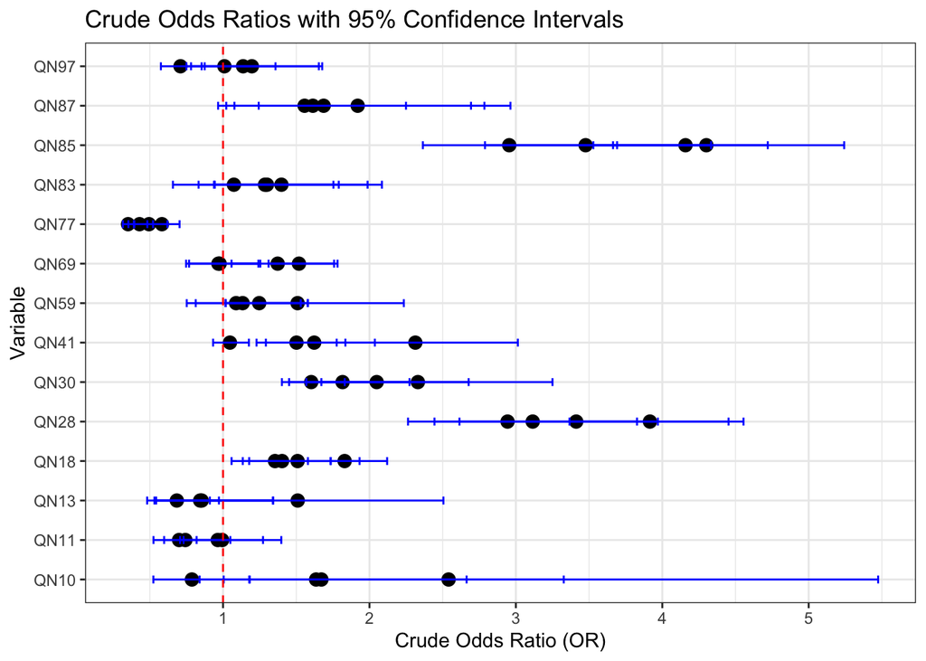

```r
ggplot(crude_or_data, aes(x = Variable, y = OR)) +
  geom_point(size = 3, color = "black") +  #points for OR
  geom_errorbar(aes(ymin = CI_lower, ymax = CI_upper), width = 0.2, color = "blue") +  #error bars for CI
  geom_hline(yintercept = 1, linetype = "dashed", color = "red") +  #line at OR = 1
  coord_flip() +
  labs(x = "Variable",
       y = "Crude Odds Ratio (OR)",
       title = "Crude Odds Ratios with 95% Confidence Intervals") +
  theme_bw()
```

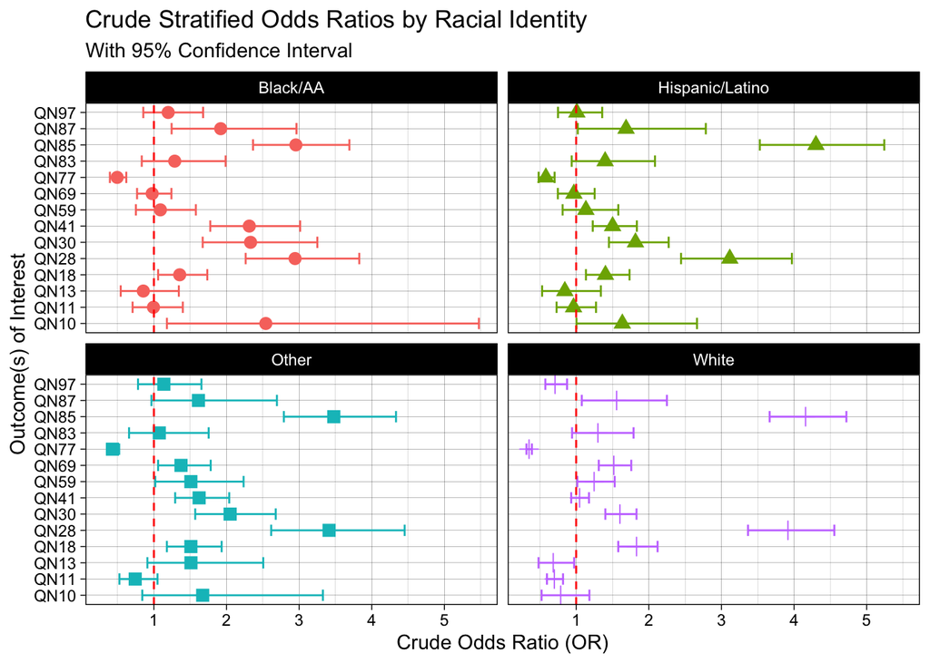

```r
ggplot(crude_or_data, aes(x = Variable, y = OR, color = Strata, shape = Strata)) +
  geom_point(size = 3) +  #points for OR
  geom_errorbar(aes(ymin = CI_lower, ymax = CI_upper), width = 0.7) +  #error bars for CI
  geom_hline(yintercept = 1, linetype = "dashed", color = "red") +  #line at OR = 1
  facet_wrap(~ Strata) +
  coord_flip() +  #flip coordinates to horizontal plot
  labs(x = "Outcome(s) of Interest",
       y = "Crude Odds Ratio (OR)",
       title = "Crude Stratified Odds Ratios by Racial Identity",
       subtitle = "With 95% Confidence Interval") +
  theme_linedraw() +
  theme(legend.position = "none")
```

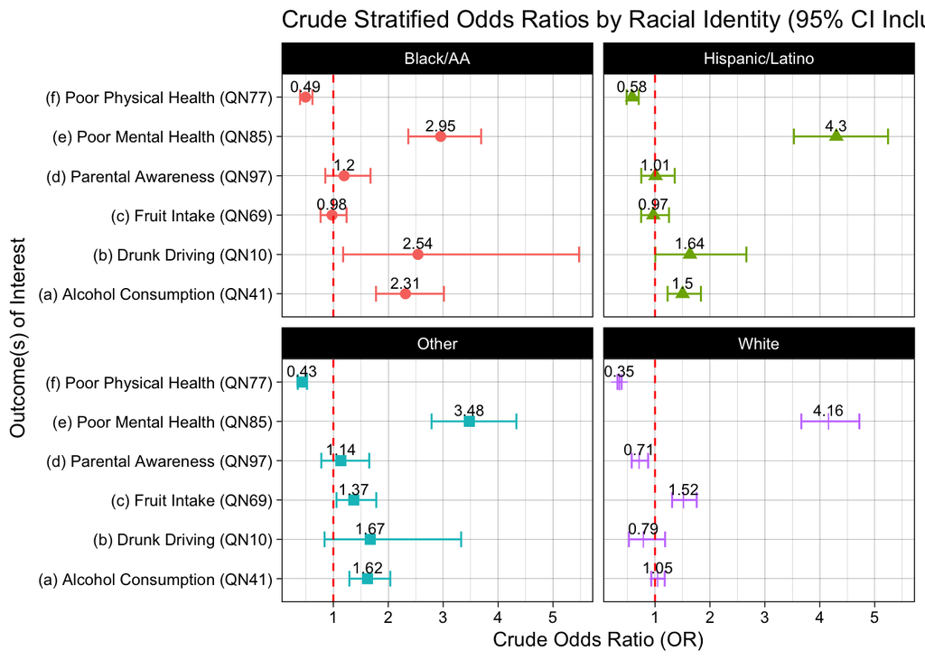

```r
crude_selected <- crude_or_data %>% #creates data frame only with those variables I reported Crude ORs for
  filter(Variable %in% c("QN10", "QN41", "QN85", "QN77", "QN69", "QN97")) %>% #selecting desired variables
  mutate(Variable = case_when(Variable == "QN10" ~ " (b) Drunk Driving (QN10)",
                              Variable == "QN41" ~ " (a) Alcohol Consumption (QN41)",
                              Variable == "QN85" ~ " (e) Poor Mental Health (QN85)",
                              Variable == "QN77" ~ " (f) Poor Physical Health (QN77)",
                              Variable == "QN69" ~ " (c) Fruit Intake (QN69)",
                              Variable == "QN97" ~ " (d) Parental Awareness (QN97)"))

crude_selected %>%
ggplot(aes(x = Variable, y = OR, color = Strata, shape = Strata)) +
  geom_point(size = 2.5) +
  geom_errorbar(aes(ymin = CI_lower, ymax = CI_upper), width = 0.4) +  #ymin/ymax specifies upper and lower limits of confidence intervals, width = end line width, errorbar = adds error bars to each point rep 95% CI
  geom_hline(yintercept = 1, linetype = "dashed", color = "red") + #horizontal dashed line @ y=1
  facet_wrap(~ Strata) + #breaks it into diff race/ethnicity/strata
    coord_flip() +  #changes to horizontal (better visual)
  labs(x = "Outcome(s) of Interest",
       y = "Crude Odds Ratio (OR)",
       title = "Crude Stratified Odds Ratios by Racial Identity (95% CI Included)") +
  theme_linedraw() +
  theme(legend.position = "none") +
  geom_text(aes(label = round(OR, 2)),  #text labels w/ OR values rounded to 2 decimal places
            vjust = -0.5, #move text slightly above points
            size = 3, #text/label size
            color = "black")
```

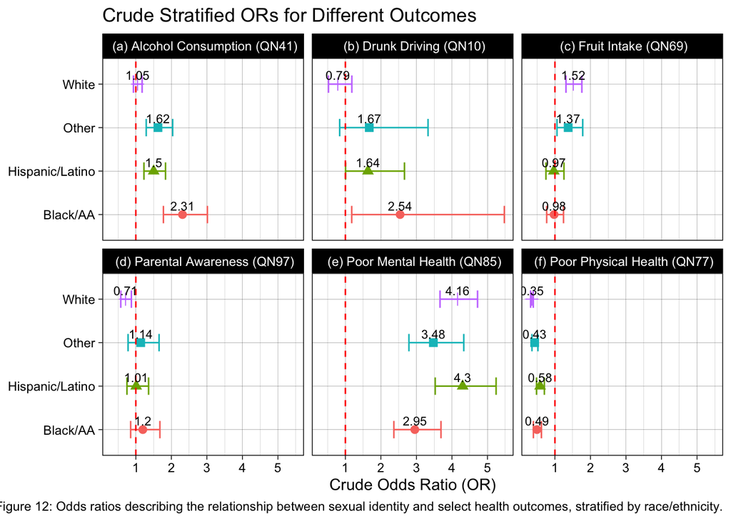

```r
ggplot(data = crude_selected, aes(x = Strata, y = OR, color = Strata, shape = Strata)) +
  geom_point(size = 2.5) +
  geom_errorbar(aes(ymin = CI_lower, ymax = CI_upper), width = 0.4) +
  geom_hline(yintercept = 1, linetype = "dashed", color = "red") +
    geom_text(aes(label = round(OR, 2)),  #text labels w/ OR values rounded to 2 decimal places
            vjust = -0.5, #move text slightly above points
            size = 3, #text/label size
            color = "black") +
  facet_wrap(~ Variable) +
  coord_flip() +
  labs(title = "Crude Stratified ORs for Different Outcomes",
       x = NULL,
       y = "Crude Odds Ratio (OR)",
       caption = "Figure 12: Odds ratios describing the relationship between sexual identity and select health outcomes, stratified by race/ethnicity.") +
  theme_linedraw() +
   theme(legend.position = "none")
```

For the outcomes of interest above, I reported the Stratified Crude ORs because the Breslow-Day test revealed significant differences (with p-values < 0.05) in how sexual identity affects the outcome across different racial groups. Reflecting on the Stratified Crude ORs will provide a clear view of how these effects vary between groups. The Mantel-Haenszel adjusted ORs, which give an overall average, might not accurately reflect these variations and could lead to ignoring important differences.

**(b)** QN10 represents the percentage of students who drove after drinking alcohol at least once in the past 30 days, among those who had driven during that period. Based on Figure 12, Black/AA, Hispanic/Latino, and Other sexual minority teens experienced 2.54, 1.64 and 1.67 odds of drunk driving, respectively, compared to heterosexual teens in their respective race/ethnicity group.

**(c)** QN69 represents the percentage of students who did not eat fruit at least once in the 7 days before the survey. White and Other sexual minority students experienced 1.52 and 1.37 odds of not consuming fruit as compared to heterosexual students in their respective ethnicty/group. Based on Figure 12, there seems to be no significant difference in Hispanic/Latino and Black/AA sexual minority students compared to their respective race/ethnicity groups.

**(d)** QN97 represents the percentage of students who reported that their parents or other adults in their family most of the time or always know where they are going or with whom they will be. Based on Figure 12, White sexual minority students experienced 0.71 times the odds (29% lower odds) that their parent/guardian knew where they were going to be, compared to their heterosexual White peers. There seems to be no significant change between the other sexual minority groups (Black/AA, Hispanic/Latino, Other) and their respective heterosexual groups.

**(e)** QN85 refers to students who reported that their mental health was not good (including stress, anxiety, and depression) most or all of the time during the 30 days before the survey. All sexual minority race/ethnicities experienced higher odds of poor mental health compared to their respective heterosexual groups.

**(f)** QN77 represents the percentage of students who were physically active at least 60 minutes per day on 5 or more days. All sexual minorities experienced lower odds of being physically active than their respective heterosexual groups.

## Plotting Mantel-Haenszel Adjusted Odd Ratios

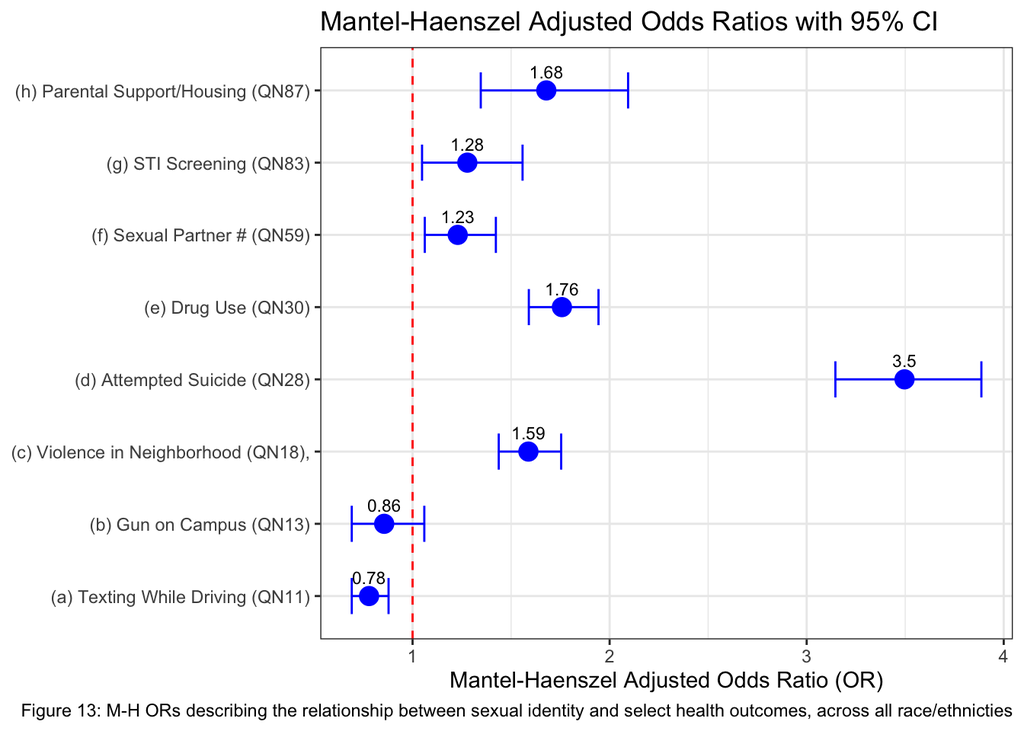

```r
mhadj_selected <- mhadj_data %>%
  filter(Variable %in% c("QN11", "QN13", "QN28", "QN83", "QN30", "QN59", "QN87", "QN18")) %>%
  mutate(Variable = case_when(Variable == "QN11" ~ "(a) Texting While Driving (QN11)",
                              Variable == "QN13" ~ "(b) Gun on Campus (QN13)",
                              Variable == "QN18" ~ "(c) Violence in Neighborhood (QN18),",
                              Variable == "QN28" ~ "(d) Attempted Suicide (QN28)",
                              Variable == "QN30" ~ "(e) Drug Use (QN30)",
                              Variable == "QN59" ~ "(f) Sexual Partner # (QN59)",
                              Variable == "QN83" ~ "(g) STI Screening (QN83)",
                              Variable == "QN87" ~ "(h) Parental Support/Housing (QN87)"))


mhadj_selected %>%
  ggplot(aes(x = Variable, y = OR)) +
  geom_point(size = 4, color = "blue") +
  geom_errorbar(aes(ymin = CI_lower, ymax = CI_upper), width = 0.5, color = "blue") +  #error bars for CI
  geom_hline(yintercept = 1, linetype = "dashed", color = "red") +  #line at OR = 1
  coord_flip() +  #flip coordinates to make horizontal
  labs(x = NULL,
       y = "Mantel-Haenszel Adjusted Odds Ratio (OR)",
       title = "Mantel-Haenszel Adjusted Odds Ratios with 95% CI",
       caption = "Figure 13: M-H ORs describing the relationship between sexual identity and select health outcomes, across all race/ethnicties") +
  theme_bw() +
   geom_text(aes(label = round(OR, 2)),  #text labels w/ OR values rounded to 2 decimal places
            vjust = -1, #move text slightly above points
            size = 3, #text/label size
            color = "black")
```

For the outcomes above, I reported and plotted the Mantel-Haenszel (M-H) Adjusted ORs because the Breslow Day test yielded p-values greater than 0.05 for each, indicating no statistical significance between race/ethnicity on these outcomes. M-H Adjusted OR essentially gives an average odds ratio across all races. This approach combines the data across all ethnic/racial groups and yields a single measure (OR) with lower and upper confidence intervals.

**(a)** QN11 in the YRBSS represents those students who reported texting while driving. Given that the OR is less than 1 (0.78), this means that overall our population of interest (sexual minority students of racial/ethnic minority status) experienced about 22% lower odds of texting while driving compared to heterosexual students in their respective race/ethnic groups.

**(b)** QN13 represents those students who reported carrying a gun to school (excluding hunting or sport-related reasons) at least one day in the past 12 months. A M-H OR of 0.86 indicates that sexual minority students experienced 14% lower odds of carrying a gun to school relative to heterosexual students.

**(c)** QN18 represents the percentage of students who ever saw someone get physically attacked, beaten, stabbed, or shot in their neighborhood. Sexual minority students experienced 1.59 times the odds of witnessing a physical attack, beat, or stabbing in their neighborhood(s) compared to heterosexual students.

**(d)** QN28 represents the percentage of students who attempted suicide. Overall, sexual minority students experienced 3.5 times the odds of attempting suicide compared to their heterosexual counterparts.

**(e)** QN30 represents the percentage of students who ever tried cigarette smoking. Based on Figure 13, sexual minority students experienced 1.76 times the odds of smoking/trying cigarette compared to their heterosexual counterparts.

**(f)** QN59 represents the percentage of students who had sexual intercourse with four or more persons during their life. Sexual minority students experienced 1.23 times the odds of having fur or more sexual partners compared to heterosexual students.

**(g)** QN83 represents the percentage of students who were tested for a sexually transmitted disease (STD) other than HIV, such as chlamydia or gonorrhea. Overall, sexual minority students experienced 1.28 times the odds of getting tested for an STD compared to heterosexual students.

**(h)** QN87 represents the percentage of students who usually did not sleep in their parent’s or guardian’s home. Based on Figure 13, sexual minority students experienced 1.68 times the odds of not sleeping in their parent/guardian’s home compared to heterosexual students.